# Sesion 3

José Manuel Toral Cruz

March 16, 2018

**FINALMENTE. MAPAS.**

Estoy obsesionado con los mapas, puedo decir que empecé a aprender a usar R porque quería hacer mapas. Este fue mi primer mapa en R.

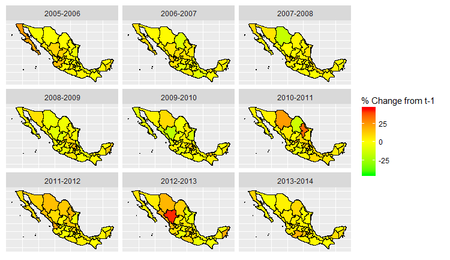

Cambios en la población reclusa del fuero común por estado.

Como en toda religión hay un libro sagrado y un o varios mesías. En los mapas en R el libro es (*Introduction to visualising spatial data in R*)[https://github.com/Robinlovelace/Creating-maps-in-R/blob/master/intro-spatial-rl.pdf] y fue escrito por la santísima trinidad: Robin Lovelace, James Cheshire y Rachel Oldroyd (¡la paz sea con ellxs!). Nosotros nos referiremos a este manual una y otra vez a lo largo de esta sesión.

¿Que exagero? Está bien. No me crean, pero visiten los siguientes sitios antes de decir cualquier cosa:

1. (Spatial.ly)[http://spatial.ly/] de Chesire.
2. (¿A dónde van los animales?)[http://wheretheanimalsgo.com/] de Chesire y Uberti
3. (Londres: La capital de la información)[http://theinformationcapital.com/]
4. (El repositorio de Robin Lovelace)[https://github.com/Robinlovelace]
5. (¿Puede la geografía salvar el mundo?)[https://www.robinlovelace.net/2017/05/02/can-geographic-data-save-the-world/]

En fin, manos a la obra.

# Preliminares

```r
x <- c("ggmap", "rgdal", "rgeos", "maptools", "dplyr", "tidyr", "leaflet")
#install.packages(x) # warning: uncommenting this may take a number of minutes
lapply(x, library, character.only = TRUE) # load the required packages
```

[output not shown]

[output not shown]

```
## Checking rgeos availability: TRUE
```

[output not shown]

```r
library("jsonlite")
library("httr")
library("stringr")
library("knitr")
```

¿Recuerdan cuándo les dije que no había más que datos de tipo caracter, numérico, números enteros, factores, vectores, mallas de datos y matrices? Les mentí. Hay un tipo de datos que también puede leer R, se trata de los *datos poligonales*. Normalmente, estos datos vienen en archivos `.shp` y se llaman Shapefiles o ESRI Shapefiles. En México, tenemos un amplísimo acervo recolectado por el INEGI de shapefiles en el (Marco Geoestadístico Nacional)[http://www.inegi.org.mx/geo/contenidos/geoestadistica/m_geoestadistico.aspx]. Esto shapefiles son gigantezcos.

Usaremos, en cambio, la base del GADM: http://gadm.org/country

# Cargar una shapefile

```r
lnd <- readOGR(dsn = "/home/manuel/Documents/MCCI/Curso_R/Sesion_3/MEX_adm_shp/MEX_adm1.shp")
```

# Manipular datos de una shapefile

```r
lnd@data
```

```
##    ID_0 ISO NAME_0 ID_1              NAME_1 HASC_1 CCN_1 CCA_1
## 0   145 MEX Mexico    1      Aguascalientes  MX.AG     0  <NA>
## 1   145 MEX Mexico    2 Baja California Sur  MX.BS     0  <NA>
## 2   145 MEX Mexico    3     Baja California  MX.BN     0  <NA>
## 3   145 MEX Mexico    4            Campeche  MX.CM     0  <NA>
## 4   145 MEX Mexico    5             Chiapas  MX.CP     0  <NA>
## 5   145 MEX Mexico    6           Chihuahua  MX.CH     0  <NA>
## 6   145 MEX Mexico    7            Coahuila  MX.CA     0  <NA>
## 7   145 MEX Mexico    8              Colima  MX.CL     0  <NA>
## 8   145 MEX Mexico    9    Distrito Federal  MX.DF     0  <NA>
## 9   145 MEX Mexico   10             Durango  MX.DU     0  <NA>
## 10  145 MEX Mexico   11          Guanajuato  MX.GJ     0  <NA>
## 11  145 MEX Mexico   12            Guerrero  MX.GR     0  <NA>
## 12  145 MEX Mexico   13             Hidalgo  MX.HI     0  <NA>
## 13  145 MEX Mexico   14             Jalisco  MX.JA     0  <NA>
```

[output cut: 51 more lines]

```r
sapply(lnd@data, class)
```

```
##      ID_0       ISO    NAME_0      ID_1    NAME_1    HASC_1     CCN_1
## "integer"  "factor"  "factor" "integer"  "factor"  "factor" "integer"
##     CCA_1    TYPE_1 ENGTYPE_1 NL_NAME_1 VARNAME_1
##  "factor"  "factor"  "factor"  "factor"  "factor"
```

```r
lnd@proj4string
```

```
## CRS arguments:
##  +proj=longlat +datum=WGS84 +no_defs +ellps=WGS84 +towgs84=0,0,0
```

# Proyectar un mapa

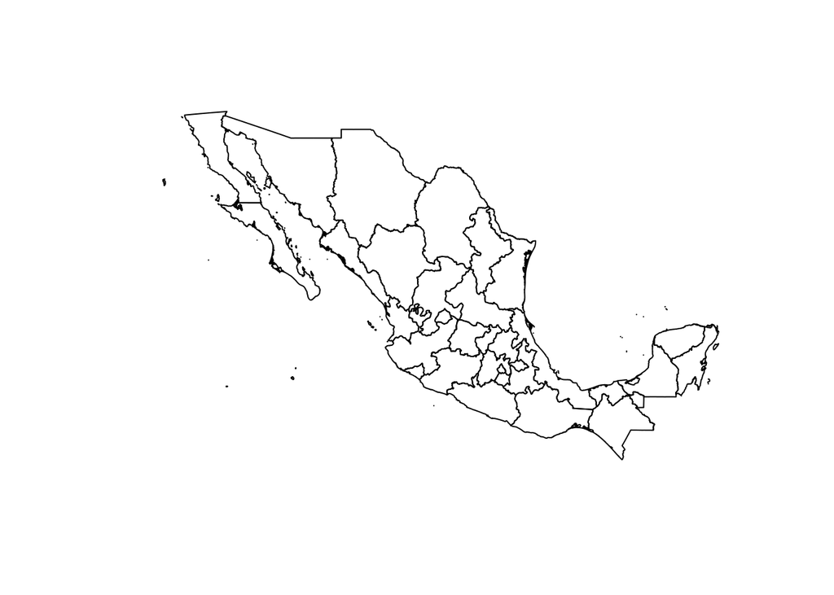

```r
plot(lnd) #Todo el mapa
```

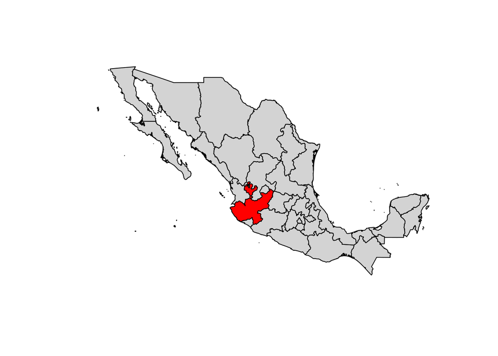

```r
plot(lnd, col = "lightgrey") #Seleccionar una parte
sel <- lnd$NAME_1== "Jalisco"
plot(lnd[ sel, ], col = "red", add = TRUE)
```

# Vamos a clusterizar el país

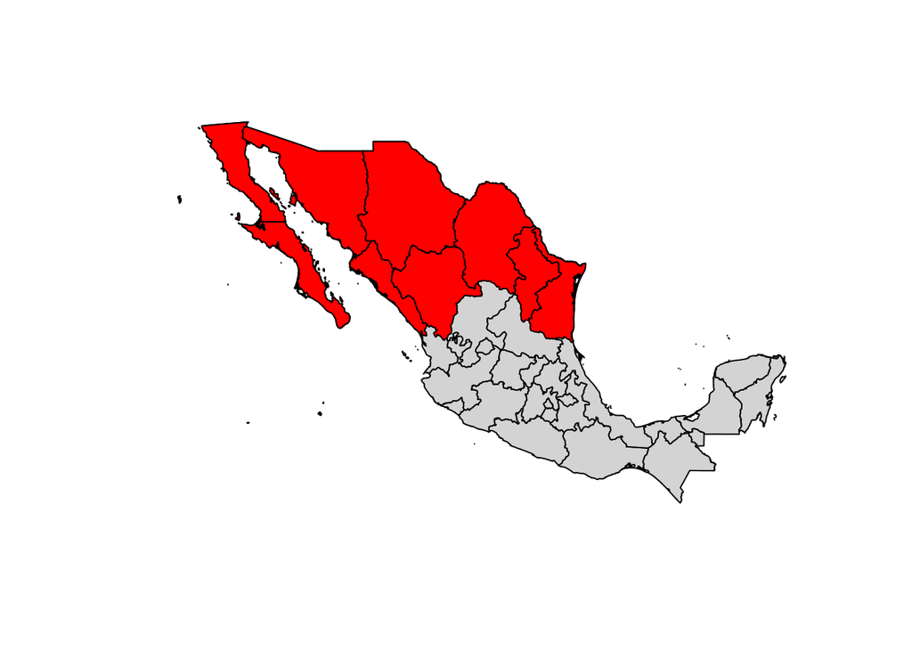

```r
easting_lnd <- coordinates(gCentroid(lnd))[[1]]
northing_lnd <- coordinates(gCentroid(lnd))[[2]]

east <- sapply(coordinates(lnd)[,1], function(x) x > easting_lnd)
north <- sapply(coordinates(lnd)[,2], function(x) x > northing_lnd)

lnd$quadrant <- "unknown" # prevent NAs in result
lnd$quadrant[north] <- "El Norte"

plot(lnd, col = "lightgrey") #Seleccionar una parte
sel <- lnd$quadrant== "El Norte"
plot(lnd[ sel, ], col = "red", add = TRUE)
```

# Unir información que no está en nuetro mapa

## 1. Cargar informacion

```r
perception_data <- read.csv("/home/manuel/Documents/MCCI/Curso_R/Sesion_3/envipe17.csv",
stringsAsFactors = FALSE)

perception_data$NAME.
```

```
##  [1] "Aguascalientes"                  "Baja California"
##  [3] "Baja California Sur"             "Campeche"
##  [5] "Coahuila de Zaragoza"            "Colima"
##  [7] "Chiapas"                         "Chihuahua"
##  [9] "Ciudad de México"                "Durango"
## [11] "Guanajuato"                      "Guerrero"
## [13] "Hidalgo"                         "Jalisco"
## [15] "Estado de México"                "Michoacán de Ocampo"
## [17] "Morelos"                         "Nayarit"
## [19] "Nuevo León"                      "Oaxaca"
## [21] "Puebla"                          "Querétaro"
## [23] "Quintana Roo"                    "San Luis Potosí"
## [25] "Sinaloa"                         "Sonora"
## [27] "Tabasco"                         "Tamaulipas"
## [29] "Tlaxcala"                        "Veracruz de Ignacio de la Llave"
## [31] "Yucatán"                         "Zacatecas"
```

```r
head(lnd$NAME_1)
```

```
## [1] Aguascalientes      Baja California Sur Baja California
## [4] Campeche            Chiapas             Chihuahua
## 32 Levels: Aguascalientes Baja California Baja California Sur ... Zacatecas
```

## 2. Unir los datos

Es importante ver que los datos sean consistentes unos con otros.

```r
lnd$NAME_1 %in% perception_data$NAME.
```

```
##  [1]  TRUE  TRUE  TRUE  TRUE  TRUE  TRUE FALSE  TRUE FALSE  TRUE  TRUE
## [12]  TRUE  TRUE  TRUE FALSE FALSE  TRUE  TRUE  TRUE  TRUE  TRUE  TRUE
## [23]  TRUE  TRUE  TRUE  TRUE  TRUE  TRUE  TRUE FALSE  TRUE  TRUE
```

```r
lnd$NAME_1[!lnd$NAME_1 %in% perception_data$NAME.]
```

```
## [1] Coahuila         Distrito Federal México           Michoacán
## [5] Veracruz
## 32 Levels: Aguascalientes Baja California Baja California Sur ... Zacatecas
```

```r
lnd$NAME_1 <- recode(lnd$NAME_1, "Coahuila"="Coahuila de Zaragoza",
                                    "Distrito Federal"="Ciudad de México",
                                    "Michoacán"="Michoacán de Ocampo",
                                    "Veracruz"="Veracruz de Ignacio de la Llave",
                                    "México"="Estado de México")

lnd$NAME_1 %in% perception_data$NAME.
```

```
##  [1] TRUE TRUE TRUE TRUE TRUE TRUE TRUE TRUE TRUE TRUE TRUE TRUE TRUE TRUE
## [15] TRUE TRUE TRUE TRUE TRUE TRUE TRUE TRUE TRUE TRUE TRUE TRUE TRUE TRUE
## [29] TRUE TRUE TRUE TRUE
```

Hacer el “join”.

```r
lnd@data <- left_join(lnd@data, perception_data, by = c('NAME_1' = 'NAME.'))
```

## 3. Hace un choropleth

```r
lnd_f <- fortify(lnd)
head(lnd_f, n = 2) # peak at the fortified data
```

```
##        long      lat order  hole piece id group
## 1 -102.1261 21.73960     1 FALSE     1  0   0.1
## 2 -102.1339 21.72841     2 FALSE     1  0   0.1
```

```r
lnd$id <- row.names(lnd)
lnd_f <- left_join(lnd_f, lnd@data)
```

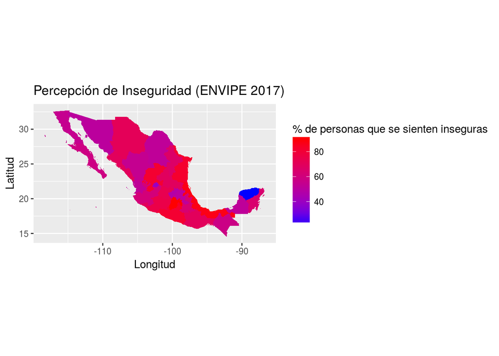

```r
map <- ggplot(lnd_f, aes(long, lat, group = group, fill = inseguro_rel)) +
geom_polygon() + coord_equal() +
labs(x = "Longitud", y = "Latitud",
fill = "% de personas que se sienten inseguras") +
ggtitle("Percepción de Inseguridad (ENVIPE 2017)") +
  scale_fill_gradient(low = "blue", high = "red")

map
```

# GGMAP

```r
omega <- geocode("Torre Omega")

map.omega <- get_map(location = as.numeric(omega),
                      color = "color",
                      maptype = "roadmap",
                      scale = 2,
                      zoom = 16)


ggmap(map.omega) + geom_point(aes(x = lon, y = lat),
                               data = omega, colour = 'red',
                               size = 4)
```

[output not shown]

[figure not shown]

```r
mapa <- get_googlemap("Mexico City", maptype = "roadmap", zoom = 12)
ruta <- route(from = "Torre Omega", to = "Delegación Iztacalco")
ggmap(mapa) +
  geom_path(aes(x = startLon, y = startLat, xend = endLon, yend = endLat),
            colour = "red", size = 2, data = ruta)
```

[output not shown]

```r
pal <- colorQuantile("YlOrRd", NULL, n = 5)

state_popup <- paste0("<strong>Estado: </strong>",
                      lnd$NAME_1,
                      "<br><strong>Porcentaje de personas inseguras: </strong>",
                      lnd$inseguro_rel)

map2 <- leaflet(data = lnd) %>%
  addProviderTiles(providers$CartoDB.Positron) %>%
  addPolygons(fillColor = ~pal(inseguro_rel),
              fillOpacity = 1,
              color = "#000000",
              weight = 1,
              popup = state_popup)
```

# Datos de Diego Valle

```r
homicidio_series <- fromJSON(str_c("https://hoyodecrimen.com",
                                   URLencode("/api/v1/df/crimes/HOMICIDIO DOLOSO/series?start_date=2014-01&end_date=2016-09")))$rows
kable(head(homicidio_series), caption = 'Homicides in CDMX since 2014')
```

Homicides in CDMX since 2014

| count | crime | date | population |
| --- | --- | --- | --- |
| 71 | HOMICIDIO DOLOSO | 2014-01 | 8785911 |
| 55 | HOMICIDIO DOLOSO | 2014-02 | 8785911 |
| 91 | HOMICIDIO DOLOSO | 2014-03 | 8785911 |
| 76 | HOMICIDIO DOLOSO | 2014-04 | 8785911 |
| 64 | HOMICIDIO DOLOSO | 2014-05 | 8785911 |
| 78 | HOMICIDIO DOLOSO | 2014-06 | 8785911 |

# Diego Valle

```r
crimen <- read.csv("/home/manuel/Documents/MCCI/Curso_R/Sesion_3/crime-lat-long.csv")
homicidio <- crimen[which(crimen$crime=="HOMICIDIO DOLOSO"),]
```

```r
cdmx <-  get_googlemap("Mexico City", maptype = "roadmap", zoom = 12)
cdmxmap <- ggmap(cdmx, extent = "device", legend = "topleft")


cdmx +
  geom_point(data = homicidio, aes(x =long, y= lat, size = .1),
             alpha=.05)


cdmxmap +
stat_density2d(
aes(x = long, y = lat, fill = ..level..,
alpha = ..level..),
size = 1, bins = 6, data = homicidio,
geom = "polygon")
```

[output not shown]